# Project Bioinformatic Resources

## Task 4: Gene set enrichment analysis

To perform the gene set enrichment analysis, we will use the `clusterProfiler` package.

```r
DEGs <- read.table("DEGs.txt", header = T, sep = "\t", as.is = T)
table(DEGs$class)
```

```
##
##    -    +    =
## 1199  884 9258
```

We use the `biomaRt` package to retrieve the `entrezgene_id` for all the genes in the `DEGs` dataset.

```r
ensembl <- useEnsembl(biomart = "ensembl", dataset = "hsapiens_gene_ensembl")
convert <- getBM(attributes = c("ensembl_gene_id", "entrezgene_id"), filters = c("ensembl_gene_id"),
    values = DEGs$ensembl_gene_id, mart = ensembl)

DEGs <- merge(DEGs, convert, by.x = "ensembl_gene_id", by.y = "ensembl_gene_id")  # include the new info in the original data frame
DEGs <- DEGs[which(!is.na(DEGs$entrezgene_id)), ]
DEGs <- DEGs[-which(duplicated(DEGs$entrezgene_id)), ]
```

We removed all the NA and duplicates in the dataset DEGs.

We created new lists for the down and up-regulated genes.

```r
# list of up-regulated genes
upDEGs <- DEGs %>%
    filter(class == "+")
# list of down-regulated genes
downDEGs <- DEGs %>%
    filter(class == "-")
```

### Performing enrichment analysis for GO biological process

```r
# biological process up regulated genes
ego_BP_up <- enrichGO(gene = upDEGs$external_gene_name, OrgDb = org.Hs.eg.db, keyType = "SYMBOL",
    ont = "BP", pAdjustMethod = "BH", pvalueCutoff = 0.05, qvalueCutoff = 0.05)
```

```r
# biological process down regulated genes
ego_BP_down <- enrichGO(gene = downDEGs$external_gene_name, OrgDb = org.Hs.eg.db,
    keyType = "SYMBOL", ont = "BP", pAdjustMethod = "BH", pvalueCutoff = 0.05, qvalueCutoff = 0.05)
```

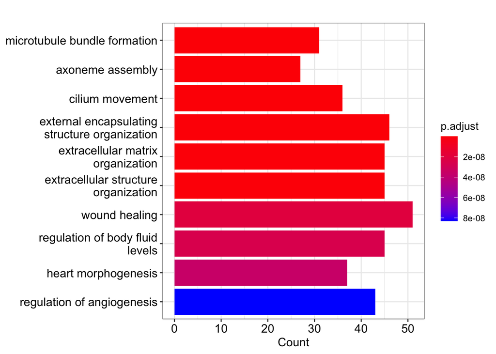

Biological process up regulated genes

```r
barplot(ego_BP_up, showCategory = 10)
```

Both the first two biological processes are related to the microtubules, which might be explained by the fact that tumour cells have a high growth rate thus the cytoskeleton is assembled over and over again. We also notice that angiogenesis is among the most enriched biological processes as we expected. In fact, angiogenesis is particularly important in tumorigenesis to allow the growth of the tumour tissue, providing nutrients to cells.

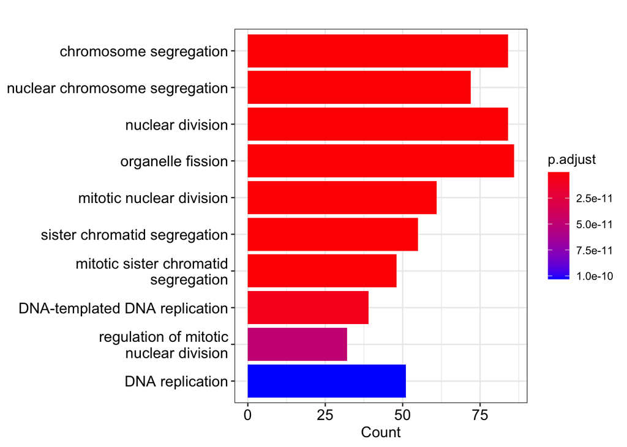

Biological process down regulated genes

```r
barplot(ego_BP_down, showCategory = 10)
```

### Performing enrichment analysis for GO molecular function

```r
# molecular function up regulated genes
ego_MF_up <- enrichGO(gene = upDEGs$external_gene_name, OrgDb = org.Hs.eg.db, keyType = "SYMBOL",
    ont = "MF", pAdjustMethod = "BH", pvalueCutoff = 0.05, qvalueCutoff = 0.05)
```

```r
# molecular function down regulated genes
ego_MF_down <- enrichGO(gene = downDEGs$external_gene_name, OrgDb = org.Hs.eg.db,
    keyType = "SYMBOL", ont = "MF", pAdjustMethod = "BH", pvalueCutoff = 0.05, qvalueCutoff = 0.05)
```

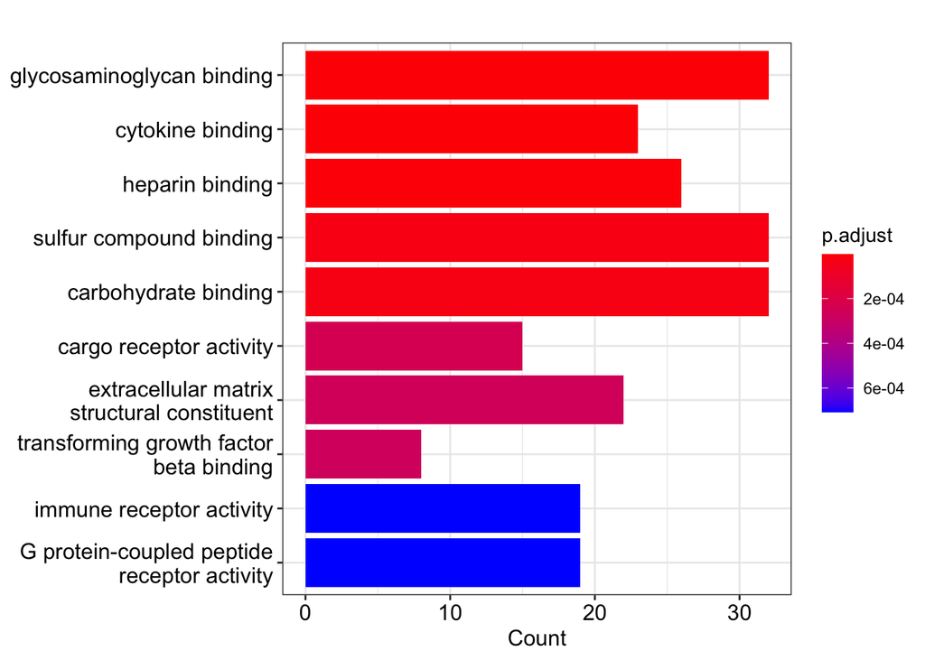

Molecular function up regulated genes

```r
barplot(ego_MF_up, showCategory = 10)
```

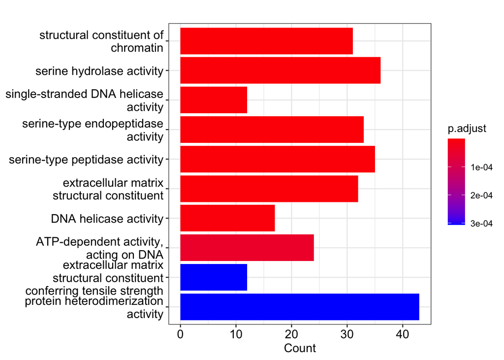

Molecular function down regulated genes

```r
barplot(ego_MF_down, showCategory = 10)
```

```r
eWP_up <- enrichWP(gene = upDEGs$entrezgene_id, organism = "Homo sapiens", pvalueCutoff = 0.05,
    qvalueCutoff = 0.1)

head(eWP_up, n = 10)
```

|  | ID | Description | GeneRatio | BgRatio | pvalue | p.adjust | qvalue | geneID | Count |
| --- | --- | --- | --- | --- | --- | --- | --- | --- | --- |
| WP2806 | WP2806 | Complement system | 19/436 | 97/8442 | 3.960197e-07 | 0.0001892974 | 0.0001725812 | 6401/729/2219/2160/7448/6404/730/653509/22918/5199/5648/11326/5806/2357/6403/5627/729238/728/1675 | 19 |
| WP545 | WP545 | Complement activation | 8/436 | 23/8442 | 1.171095e-05 | 0.0027989174 | 0.0025517547 | 732/729/730/5199/5648/713/712/1675 | 8 |
| WP558 | WP558 | Complement and coagulation cascades | 12/436 | 58/8442 | 3.152788e-05 | 0.0050234421 | 0.0045798393 | 729/1361/7450/730/5648/713/712/7056/5627/2157/728/1675 | 12 |
| WP2431 | WP2431 | Spinal cord injury | 18/436 | 121/8442 | 4.427616e-05 | 0.0052910008 | 0.0048237708 | 2920/4842/57556/6347/1958/3164/7538/3569/7099/9353/2353/361/713/6403/627/6586/5320/358 | 18 |
| WP5094 | WP5094 | Orexin receptor pathway | 24/436 | 201/8442 | 1.015995e-04 | 0.0087342052 | 0.0079629178 | 6401/862/2920/4616/1839/8013/1958/1959/3164/2354/3949/5468/3569/9314/2890/1346/2353/5581/3400/4023/1960/23764/23237/1589 | 24 |
| WP5090 | WP5090 | Complement system in neuronal development and plasticity | 16/436 | 107/8442 | 1.096344e-04 | 0.0087342052 | 0.0079629178 | 732/729/2219/7448/730/5199/5648/8547/81035/1524/713/712/2621/5627/728/1675 | 16 |

```r
eWP_down <- enrichWP(gene = downDEGs$entrezgene_id, organism = "Homo sapiens", pvalueCutoff = 0.05,
    qvalueCutoff = 0.1)

head(eWP_down, n = 10)
```

|  | ID | Description | GeneRatio | BgRatio | pvalue | p.adjust | qvalue | geneID | Count |
| --- | --- | --- | --- | --- | --- | --- | --- | --- | --- |
| WP2446 | WP2446 | Retinoblastoma gene in cancer | 26/618 | 90/8442 | 5.976882e-10 | 3.107978e-07 | 2.850029e-07 | 1870/54443/4175/4998/24137/8318/5427/1869/4173/898/1871/7272/7153/891/10733/890/1111/9133/5984/993/4176/81620/983/6241/9134/7298 | 26 |
| WP2361 | WP2361 | Gastric cancer network 1 | 13/618 | 28/8442 | 2.054960e-08 | 4.361461e-06 | 3.999477e-06 | 6790/22974/4605/4173/1894/1063/7153/9585/56992/6286/144455/11065/121504 | 13 |
| WP179 | WP179 | Cell cycle | 28/618 | 120/8442 | 2.516227e-08 | 4.361461e-06 | 3.999477e-06 | 1870/4171/4175/4998/23594/8318/990/1869/4173/898/1871/7272/991/9088/891/9700/890/1029/1111/9133/995/993/9232/4176/5347/699/983/9134 | 28 |
| WP1604 | WP1604 | Codeine and morphine metabolism | 9/618 | 16/8442 | 4.091055e-07 | 4.391632e-05 | 4.027145e-05 | 1244/1565/8714/7363/54578/54600/54658/54576/54575 | 9 |
| WP45 | WP45 | G1 to S cell cycle control | 18/618 | 64/8442 | 4.222724e-07 | 4.391632e-05 | 4.027145e-05 | 1870/4171/4175/4998/23594/8318/5427/1869/4173/898/1871/891/148327/1029/993/4176/983/9134 | 18 |
| WP466 | WP466 | DNA replication | 13/618 | 42/8442 | 5.366172e-06 | 4.650682e-04 | 4.264694e-04 | 55388/4171/4175/4998/23594/8318/990/5427/4173/51053/5984/4176/81620 | 13 |
| WP4240 | WP4240 | Regulation of sister chromatid separation at the metaphase-anaphase transition | 7/618 | 15/8442 | 4.168136e-05 | 3.096330e-03 | 2.839347e-03 | 991/9700/1062/701/4085/9232/699 | 7 |
| WP698 | WP698 | Glucuronidation | 9/618 | 26/8442 | 5.735318e-05 | 3.541417e-03 | 3.247494e-03 | 7358/7363/54578/54600/54658/54576/54575/54577/54657 | 9 |
| WP4016 | WP4016 | DNA IR-damage and cellular response via ATR | 17/618 | 81/8442 | 6.129375e-05 | 3.541417e-03 | 3.247494e-03 | 672/5888/4171/63967/8318/1869/2305/83990/55215/2177/1111/995/9401/5347/2237/983/9156 | 17 |
| WP2525 | WP2525 | Trans-sulfuration, one-carbon metabolism and related pathways | 15/618 | 68/8442 | 9.059661e-05 | 4.711024e-03 | 4.320028e-03 | 2729/2730/10797/1789/2571/23743/29968/570/55224/4143/102724560/875/2877/7298/6472 | 15 |

## Task 5: Visualization of the enriched pathway

```r
logFC <- upDEGs$logFC
names(logFC) <- upDEGs$entrezgene_id
pathview(gene.data = logFC, pathway.id = "WP2446", species = "human")
```

[output not shown]

```r
eWP_KEGG <- enrichKEGG(gene = upDEGs$entrezgene_id, organism = "human", pvalueCutoff = 0.05,
    qvalueCutoff = 0.1)

head(eWP_KEGG, n = 20)
```

|  | ID | Description | GeneRatio | BgRatio | pvalue | p.adjust | qvalue | geneID | Count |
| --- | --- | --- | --- | --- | --- | --- | --- | --- | --- |
| hsa05144 | hsa05144 | Malaria | 13/382 | 50/8461 | 2.045971e-07 | 3.077765e-05 | 2.686624e-05 | 6401/1440/6347/948/3569/2995/7099/6403/3040/3039/2532/3043/5175 | 13 |
| hsa04610 | hsa04610 | Complement and coagulation cascades | 17/382 | 86/8461 | 2.144784e-07 | 3.077765e-05 | 2.686624e-05 | 732/729/1361/2160/7448/7450/730/5648/11326/713/712/2/7056/5627/2157/728/1675 | 17 |
| hsa04270 | hsa04270 | Vascular smooth muscle contraction | 17/382 | 134/8461 | 1.038943e-04 | 9.939223e-03 | 8.676086e-03 | 10203/1906/50487/10268/196883/10266/4628/4629/185/2977/114/94274/255189/4881/5319/5581/5320 | 17 |
| hsa04061 | hsa04061 | Viral protein interaction with cytokine and cytokine receptor | 14/382 | 100/8461 | 1.469697e-04 | 1.054508e-02 | 9.204945e-03 | 53832/2920/6369/6347/8809/51554/3569/3577/2921/5473/1524/3579/6368/6358 | 14 |
| hsa04614 | hsa04614 | Renin-angiotensin system | 6/382 | 23/8461 | 4.269912e-04 | 2.382406e-02 | 2.079635e-02 | 1511/185/1636/1359/186/4311 | 6 |
| hsa03320 | hsa03320 | PPAR signaling pathway | 11/382 | 75/8461 | 4.980639e-04 | 2.382406e-02 | 2.079635e-02 | 10580/33/5468/948/1593/6258/79966/2171/2167/4973/4023 | 11 |
| hsa04380 | hsa04380 | Osteoclast differentiation | 15/382 | 128/8461 | 6.235812e-04 | 2.501803e-02 | 2.183859e-02 | 7305/6688/10326/54/11024/4688/2354/3727/5468/2215/7048/2353/126014/9021/353514 | 15 |
| hsa04514 | hsa04514 | Cell adhesion molecules | 17/382 | 157/8461 | 6.973666e-04 | 2.501803e-02 | 2.183859e-02 | 6401/51208/8516/64115/6404/90952/58494/22854/257194/947/6403/53842/1003/23705/7122/6693/5175 | 17 |
| hsa04060 | hsa04060 | Cytokine-cytokine receptor interaction | 26/382 | 295/8461 | 8.073811e-04 | 2.574649e-02 | 2.247447e-02 | 53832/2920/3568/6369/1440/6347/2690/3977/9173/8809/650/51554/3569/90865/94/3577/7048/2921/5473/1524/3575/3579/3563/2662/6368/6358 | 26 |
| hsa04924 | hsa04924 | Renin secretion | 10/382 | 69/8461 | 9.796110e-04 | 2.811484e-02 | 2.454183e-02 | 153/1906/5153/5593/185/2977/1636/154/4881/358 | 10 |

[output cut: 3 more lines]

## Task 6: Enrichment score transcription factors

```r
promoter_regions <- getSequence(id = downDEGs$ensembl_gene_id, type = "ensembl_gene_id",
    seqType = "gene_flank", upstream = 500, mart = ensembl)
```

```r
data(PWMLogn.hg19.MotifDb.Hsap)
seq <- lapply(promoter_regions$gene_flank, function(x) DNAString(x))
```

```r
enriched_TFs = motifEnrichment(seq, PWMLogn.hg19.MotifDb.Hsap, score = "affinity")
```

```
## Calculating motif enrichment scores ...
```

```r
report = groupReport(enriched_TFs)
report
```

```
## An object of class 'MotifEnrichmentReport':
##        rank target              id        raw.score              p.value
## 1         1  PGAM2           PGAM2 7.47058707343782 2.41159784654048e-86
## 2         2  TFAP4      M2944_1.02 3.42391273544219 3.36836197404242e-84
## 3         3    SP2             SP2  119.54842162525 6.25197615973972e-84
## 4         4  CEBPB      M4556_1.02 2.30767167521828  1.7054813305699e-83
## 5         5   JUND      M4506_1.02  6.8634137704217 1.50332672791467e-81
## 6         6   MAFK      M4573_1.02 2.41935358645508 4.83938302985492e-81
## 7         7  ZMAT2           ZMAT2 2.16420212862343 9.19698805317131e-81
## 8         8    JUN      M4591_1.02 2.76520576103839 2.36897498529839e-80
## 9         9   KLF5            KLF5 30.1023912345585 2.91297830264159e-79
## 10       10    NNT             NNT 1.87741003326598 6.17885793377267e-79
## ...     ...    ...             ...              ...                  ...
## 2287 2001.5  Oct-1 NBT06/Oct-1.pwm 1.72351938773035                    1
##          top.motif.prop
## 1     0.177364864864865
## 2     0.178209459459459
## 3     0.185810810810811
## 4     0.174831081081081
## 5     0.185810810810811
## 6     0.171452702702703
## 7     0.163851351351351
## 8     0.168074324324324
## 9     0.158783783783784
## 10    0.173986486486486
## ...                 ...
## 2287 0.0278716216216216
```

## Task 7

**Select one among the top enriched TFs, compute the empirical distributions of scores for all PWMs that you find in MotifDB for the selected TF and determine for all of them the distribution (log2) threshold cutoff at 99.75%.**

```r
tfs <- report$target[1]

tfs_motifs = subset(MotifDb, organism == "Hsapiens" & geneSymbol == tfs)
# tfs_motifs

PWM = toPWM(as.list(tfs_motifs))
PWM
```

```
## $`Hsapiens-hPDI-PGAM2`
## An object of class 'PWM'
## ID: Hsapiens-hPDI-PGAM2
## Target name: Hsapiens-hPDI-PGAM2
## Frequency matrix:
## $pfm
##    1  2  3  4  5  6  7  8
## A  0  0  0 25  0 12 12  0
## C  0 12 12 25  0  0  0  0
## G 50 38 38  0 50 38 38 50
## T  0  0  0  0  0  0  0  0
## Position weight matrix (PWM):
## $pwm
##           1          2          3          4         5          6          7
## A -5.672425 -5.6724253 -5.6724253  0.9857861 -5.672425 -0.0577155 -0.0577155
## C -5.672425 -0.0577155 -0.0577155  0.9857861 -5.672425 -5.6724253 -5.6724253
## G  1.978626  1.5849625  1.5849625 -5.6724253  1.978626  1.5849625  1.5849625
## T -5.672425 -5.6724253 -5.6724253 -5.6724253 -5.672425 -5.6724253 -5.6724253
##           8
## A -5.672425
## C -5.672425
## G  1.978626
## T -5.672425
## With background nucleotide frequencies which also serve as pseudo-count:
## $prior.params
##    A    C    G    T
## 0.25 0.25 0.25 0.25
```

```r
ecdf = motifEcdf(PWM, organism = "hg19", quick = TRUE)  # calculate for each motif of my gene the empirical distribution scores
# ecdf

thresholds = lapply(ecdf, function(x) log2(quantile(x, 0.9975)))  # for each of the distribution, take the quantile as reference
# thresholds
```

## Task 8

**Identify which up-regulated (or down-regulated depending on the choice you made at point 7) genes have a region in their promoter (defined as previously) with binding scores above the computed thresholds for any of the previously selected PWMs. Use pattern matching as done during the course**

```r
scores = motifScores(seq, PWM, raw.scores = FALSE, cutoff = unlist(thresholds))  # in my promoters, i want to spot the regions that have higher probability to bind my transcription factors -> the function motifScores performs the pattern matching

head(scores)
```

```
##      Hsapiens-hPDI-PGAM2
## [1,]                   4
## [2,]                   4
## [3,]                   1
## [4,]                   2
## [5,]                   7
## [6,]                   2
```

```r
fractions_99_75 = c()
fractions_99_75 = c(fractions_99_75, length(which(apply(scores, 1, sum) > 0))/100)
fractions_99_75
```

```
## [1] 10.07
```

```r
highscore_seq <- which(apply(scores, 1, sum) > 0)
down_DEGs[highscore_seq, ]  # keeping only sequences which have higher score than threshold
```

|  | ensembl_gene_id | external_gene_name | length | logFC | logCPM | F | PValue | FDR | class |
| --- | --- | --- | --- | --- | --- | --- | --- | --- | --- |
| ENSG00000130234 | ENSG00000130234 | ACE2 | 112670 | -1.500042 | 2.537010 | 26.937869 | 1.079020e-06 | 2.728162e-06 | - |
| ENSG00000139998 | ENSG00000139998 | RAB15 | 27412 | -1.500270 | 5.323017 | 69.320705 | 4.067450e-13 | 2.499010e-12 | - |
| ENSG00000088826 | ENSG00000088826 | SMOX | 66767 | -1.503458 | 3.277682 | 64.145641 | 1.984204e-12 | 1.092861e-11 | - |
| ENSG00000240972 | ENSG00000240972 | MIF | 844 | -1.503544 | 7.546681 | 92.334101 | 6.137106e-16 | 6.059647e-15 | - |
| ENSG00000085465 | ENSG00000085465 | OVGP1 | 13416 | -1.504675 | 1.551978 | 63.298344 | 2.584577e-12 | 1.405181e-11 | - |
| ENSG00000183196 | ENSG00000183196 | CHST6 | 23393 | -1.506132 | 3.263537 | 19.530436 | 2.481383e-05 | 5.290496e-05 | - |
| ENSG00000121380 | ENSG00000121380 | BCL2L14 | 161240 | -1.509102 | 1.183644 | 43.158553 | 2.183470e-09 | 7.835206e-09 | - |
| ENSG00000112312 | ENSG00000112312 | GMNN | 11168 | -1.509589 | 3.686536 | 115.170464 | 2.031996e-18 | 3.317391e-17 | - |
| ENSG00000064300 | ENSG00000064300 | NGFR | 19715 | -1.509766 | 2.645172 | 14.811638 | 2.076678e-04 | 3.889890e-04 | - |
| ENSG00000170779 | ENSG00000170779 | CDCA4 | 11510 | -1.512081 | 3.782223 | 126.202373 | 1.597558e-19 | 3.276415e-18 | - |

[output cut: 997 more lines]